# Math7340 HW12

Chengbo Gu

### Problem 1 (60 points) Analysis of the ALL data set

##### (a) Define an indicator variable ALL.fac such that ALL.fac=1 for T-cell patients and ALL.fac=2 for B-cell patients.

```r
library(ALL)
```

```r
data(ALL)
ALL.fac <- as.numeric(ALL$BT)
ALL.fac[ALL.fac <= 5] = 1
ALL.fac[ALL.fac > 5] = 2
```

##### (b) Plot the histograms for the first three genes’ expression values in one row.

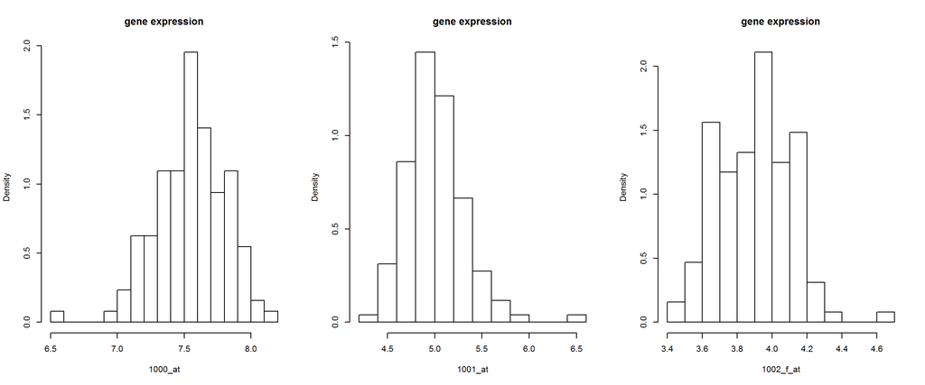

```r
par(mfrow=c(1,3))
for (i in 1:3) {
  hist(exprs(ALL)[i,], main="gene expression", nclass=15,
       freq=FALSE, xlab=rownames(exprs(ALL))[i])
}
```

##### (c) Plot the pairwise scatterplots for the first five genes.

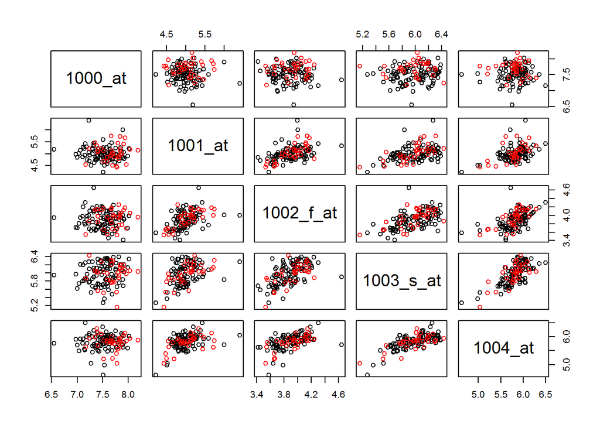

```r
firstFive <- t(exprs(ALL)[1:5,])
pairs(firstFive, col=ALL.fac)
```

##### (d) Do a 3D scatterplot for the genes “39317_at”, “32649_at” and “481_at”, and color according to ALL.fac (give different colors for B-cell versus T-cell patients). Can the two patient groups be distinguished using these three genes?

```r
rowname <- rownames(exprs(ALL))
index39317 <- grep("^39317_at$", rowname)
index32649 <- grep("^32649_at$", rowname)
index481 <- grep("^481_at$", rowname)

data <- t(exprs(ALL)[c(index39317, index32649, index481),])
```

```r
require(scatterplot3d)
```

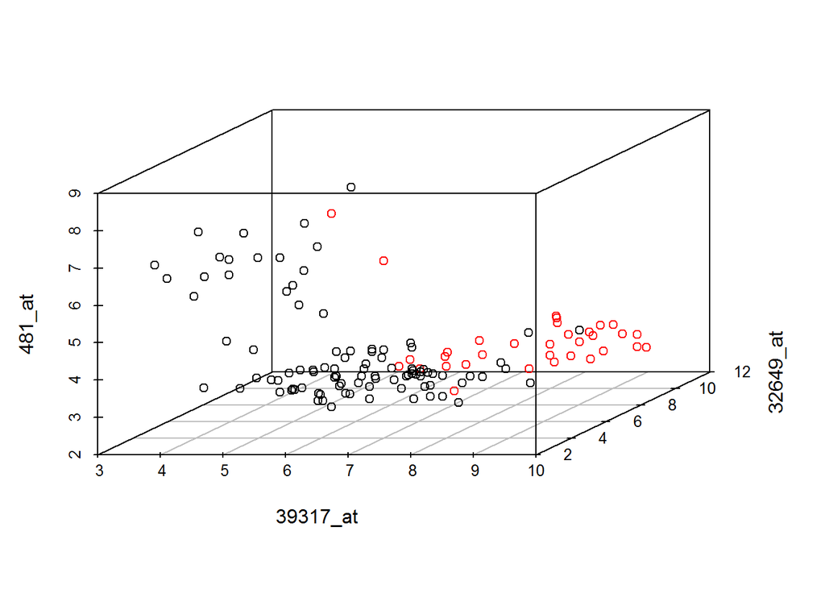

```r
scatterplot3d(data, color=ALL.fac)
```

From the 3D plot, we conclude that two patient groups could be distinguished using these three genes.

##### (e) Do K-means clustering for K=2 and K=3 using the three genes in (d). Compare the resulting clusters with the two patient groups. Are the two groups discovered by the clustering analysis?

```r
cl.2mean <- kmeans(data, centers=2, nstart = 10)
table(ALL.fac, cl.2mean$cluster)
```

```
##
## ALL.fac  1  2
##       1 74 21
##       2  2 31
```

```r
cl.3mean <- kmeans(data, centers=3, nstart = 10)
table(ALL.fac, cl.3mean$cluster)
```

```
##
## ALL.fac  1  2  3
##       1 70 20  5
##       2  3  2 28
```

Yes, the two groups are discovered by K-means clustering when K = 3.

##### (f) Carry out the PCA on the ALL data set with scaled variables. What proportion of variance is explained by the first principal component? By the second principal component?

```r
PCA <- prcomp(exprs(ALL), scale=TRUE)
summary(PCA)
```

```
## Importance of components:
##                            PC1     PC2     PC3     PC4     PC5     PC6
## Standard deviation     10.9450 1.10132 0.93237 0.75341 0.62938 0.57412
## Proportion of Variance  0.9359 0.00948 0.00679 0.00443 0.00309 0.00258
## Cumulative Proportion   0.9359 0.94536 0.95215 0.95658 0.95968 0.96225
##                            PC7    PC8     PC9    PC10    PC11    PC12
## Standard deviation     0.53197 0.5065 0.45455 0.44240 0.41633 0.38966
## Proportion of Variance 0.00221 0.0020 0.00161 0.00153 0.00135 0.00119
## Cumulative Proportion  0.96446 0.9665 0.96808 0.96961 0.97096 0.97215
##                           PC13    PC14   PC15    PC16   PC17    PC18
## Standard deviation     0.37283 0.34734 0.3387 0.32576 0.3191 0.31055
## Proportion of Variance 0.00109 0.00094 0.0009 0.00083 0.0008 0.00075
## Cumulative Proportion  0.97324 0.97418 0.9751 0.97590 0.9767 0.97745
##                          PC19    PC20    PC21    PC22    PC23    PC24
## Standard deviation     0.2987 0.29401 0.27942 0.27543 0.26333 0.25743
## Proportion of Variance 0.0007 0.00068 0.00061 0.00059 0.00054 0.00052
## Cumulative Proportion  0.9781 0.97882 0.97943 0.98003 0.98057 0.98109
##                          PC25    PC26    PC27    PC28    PC29   PC30
## Standard deviation     0.2529 0.24844 0.24440 0.23997 0.23253 0.2276
## Proportion of Variance 0.0005 0.00048 0.00047 0.00045 0.00042 0.0004
## Cumulative Proportion  0.9816 0.98207 0.98254 0.98299 0.98341 0.9838
##                           PC31    PC32    PC33    PC34    PC35    PC36
## Standard deviation     0.22140 0.21872 0.21464 0.21034 0.20851 0.20687
## Proportion of Variance 0.00038 0.00037 0.00036 0.00035 0.00034 0.00033
## Cumulative Proportion  0.98420 0.98457 0.98493 0.98527 0.98561 0.98595
##                           PC37    PC38    PC39    PC40    PC41    PC42
## Standard deviation     0.20443 0.20277 0.19800 0.19320 0.19076 0.18964
## Proportion of Variance 0.00033 0.00032 0.00031 0.00029 0.00028 0.00028
## Cumulative Proportion  0.98628 0.98660 0.98690 0.98719 0.98748 0.98776
##                           PC43    PC44    PC45    PC46    PC47    PC48
## Standard deviation     0.18781 0.18476 0.18378 0.18014 0.17825 0.17590
## Proportion of Variance 0.00028 0.00027 0.00026 0.00025 0.00025 0.00024
## Cumulative Proportion  0.98804 0.98830 0.98857 0.98882 0.98907 0.98931
##                           PC49    PC50    PC51    PC52    PC53    PC54
## Standard deviation     0.17427 0.17334 0.17162 0.17050 0.16915 0.16838
## Proportion of Variance 0.00024 0.00023 0.00023 0.00023 0.00022 0.00022
## Cumulative Proportion  0.98955 0.98978 0.99001 0.99024 0.99046 0.99068
##                           PC55    PC56    PC57   PC58   PC59   PC60
## Standard deviation     0.16606 0.16457 0.16213 0.1610 0.1596 0.1582
## Proportion of Variance 0.00022 0.00021 0.00021 0.0002 0.0002 0.0002
```

[output cut: 34 more lines]

```
## Standard deviation     0.10877 0.10786 0.10707 0.10695 0.10524 0.10380
## Proportion of Variance 0.00009 0.00009 0.00009 0.00009 0.00009 0.00008
## Cumulative Proportion  0.99862 0.99871 0.99880 0.99889 0.99898 0.99906
##                          PC116   PC117   PC118   PC119   PC120   PC121
## Standard deviation     0.10283 0.10237 0.10169 0.10030 0.09900 0.09793
## Proportion of Variance 0.00008 0.00008 0.00008 0.00008 0.00008 0.00007
## Cumulative Proportion  0.99915 0.99923 0.99931 0.99939 0.99946 0.99954
##                          PC122   PC123   PC124   PC125   PC126   PC127
## Standard deviation     0.09682 0.09573 0.09494 0.09312 0.09174 0.09121
## Proportion of Variance 0.00007 0.00007 0.00007 0.00007 0.00007 0.00006
## Cumulative Proportion  0.99961 0.99968 0.99975 0.99982 0.99989 0.99995
##                          PC128
## Standard deviation     0.07754
## Proportion of Variance 0.00005
## Cumulative Proportion  1.00000
```

93.59% of variance is explained by the first principal component.

0.948% of variance is explained by the second principal component.

##### (g) Do a biplot of the first two principal components. Observe the pattern for the loadings. What info is the first principal component summarizing?

```r
print(c(t(PCA$rotation[,1])), digits=3)
```

```
##   [1] -0.0897 -0.0881 -0.0889 -0.0872 -0.0884 -0.0882 -0.0877 -0.0883
##   [9] -0.0886 -0.0892 -0.0887 -0.0885 -0.0887 -0.0887 -0.0886 -0.0895
##  [17] -0.0881 -0.0890 -0.0895 -0.0890 -0.0896 -0.0883 -0.0890 -0.0885
##  [25] -0.0895 -0.0895 -0.0882 -0.0872 -0.0893 -0.0881 -0.0891 -0.0887
##  [33] -0.0891 -0.0891 -0.0895 -0.0886 -0.0888 -0.0869 -0.0884 -0.0881
##  [41] -0.0895 -0.0869 -0.0886 -0.0894 -0.0879 -0.0888 -0.0895 -0.0887
##  [49] -0.0866 -0.0890 -0.0882 -0.0863 -0.0887 -0.0885 -0.0876 -0.0883
##  [57] -0.0880 -0.0879 -0.0884 -0.0876 -0.0879 -0.0894 -0.0873 -0.0882
##  [65] -0.0883 -0.0884 -0.0888 -0.0895 -0.0891 -0.0889 -0.0883 -0.0885
##  [73] -0.0898 -0.0883 -0.0884 -0.0889 -0.0899 -0.0892 -0.0895 -0.0893
##  [81] -0.0890 -0.0888 -0.0870 -0.0882 -0.0894 -0.0896 -0.0898 -0.0862
##  [89] -0.0886 -0.0876 -0.0867 -0.0855 -0.0883 -0.0876 -0.0896 -0.0886
##  [97] -0.0882 -0.0893 -0.0881 -0.0872 -0.0852 -0.0873 -0.0887 -0.0865
## [105] -0.0886 -0.0876 -0.0887 -0.0879 -0.0890 -0.0876 -0.0887 -0.0863
## [113] -0.0874 -0.0893 -0.0873 -0.0866 -0.0883 -0.0890 -0.0887 -0.0868
## [121] -0.0890 -0.0885 -0.0879 -0.0886 -0.0886 -0.0883 -0.0885 -0.0886
```

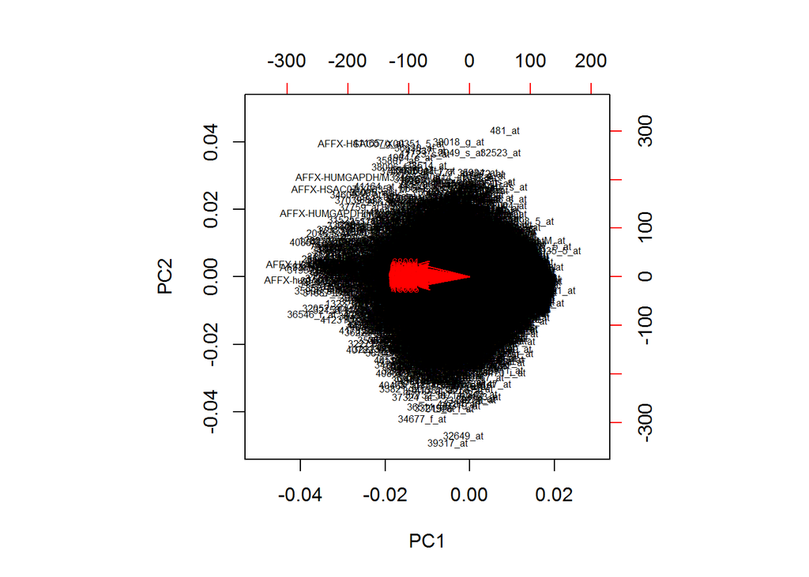

```r
biplot(PCA, xlim=c(-0.05,0.03), ylim=c(-0.05,0.05), cex=0.5)
```

We can see that the loadings for PC1 are all negative and have very similar size (all between -0.08 and -0.09). So PC1 is essentially the negative average of all variables.

##### (h) For the second principal component PC2, print out the three genes with biggest PC2 values and the three genes with smallest PC2 values.

```r
o <- order(PCA$x[,2])

numOfGenes <- dim(exprs(ALL))[1]
rowname[ o[ (numOfGenes-2) : numOfGenes]]
```

```
## [1] "41165_g_at" "38018_g_at" "481_at"
```

```r
rowname[o[1:3]]
```

```
## [1] "39317_at"   "32649_at"   "34677_f_at"
```

##### (i) Find the gene names and chromosomes for the gene with biggest PC2 value and the gene with smallest PC2 value. (Hint: review Module 10 on searching the annotation.)

```r
library(hgu95av2.db)
```

```r
biggest <- rowname[o[numOfGenes]]
smallest <- rowname[o[1]]
```

gene name and chromosome for the gene with biggest PC2 value

```r
get(biggest, env = hgu95av2GENENAME)
```

```
## [1] "SNF related kinase"
```

```r
get(biggest, env = hgu95av2CHR)
```

```
## [1] "3"
```

gene name and chromosome for the gene with smallest PC2 value

```r
get(smallest, env = hgu95av2GENENAME)
```

```
## [1] "cytidine monophospho-N-acetylneuraminic acid hydroxylase, pseudogene"
```

```r
get(smallest, env = hgu95av2CHR)
```

```
## [1] "6"
```

### Problem 2 (40 points) Variables scaling and PCA in the iris data set

##### In this module and last module, we mentioned that the variables are often scaled before doing the PCA or the clustering analysis. By “scaling a variable”, we mean to apply a linear transformation to center the observations to have mean zero and standard deviation one. In last module, we also mentioned using the correlation-based dissimilarity measure versus using the Euclidean distance in clustering analysis. It turns out that the correlation-based dissimilarity measure is proportional to the squared Euclidean distance on the scaled variables. We check this on the iris data set. And we compare the PCA on scaled versus unscaled variables for the iris data set.

##### (a) Create a data set consisting of the first four numerical variables in the iris data set (That is, to drop the last variable Species which is categorical). Then make a scaled data set that centers each of the four variables (columns) to have mean zero and variance one.

```r
data <- data.frame(iris[,1:4])
scaled.data <- scale(data)

colMeans(scaled.data)
```

```
##  Sepal.Length   Sepal.Width  Petal.Length   Petal.Width
## -4.480675e-16  2.035409e-16 -2.844947e-17 -3.714621e-17
```

```r
apply(scaled.data, 2, sd)
```

```
## Sepal.Length  Sepal.Width Petal.Length  Petal.Width
##            1            1            1            1
```

The data is scaled now with mean 0 and sd 1.

##### (b) Calculate the correlations between the columns of the data sets using the cor() function. Show that these correlations are the same for scaled and the unscaled data sets.

```r
cor(data)
```

```
##              Sepal.Length Sepal.Width Petal.Length Petal.Width
## Sepal.Length    1.0000000  -0.1175698    0.8717538   0.8179411
## Sepal.Width    -0.1175698   1.0000000   -0.4284401  -0.3661259
## Petal.Length    0.8717538  -0.4284401    1.0000000   0.9628654
## Petal.Width     0.8179411  -0.3661259    0.9628654   1.0000000
```

```r
cor(scaled.data)
```

```
##              Sepal.Length Sepal.Width Petal.Length Petal.Width
## Sepal.Length    1.0000000  -0.1175698    0.8717538   0.8179411
## Sepal.Width    -0.1175698   1.0000000   -0.4284401  -0.3661259
## Petal.Length    0.8717538  -0.4284401    1.0000000   0.9628654
## Petal.Width     0.8179411  -0.3661259    0.9628654   1.0000000
```

These correlations are the same for scaled and the unscaled data sets

##### (c) Calculate the Euclidean distances between the columns of the scaled data set using dist() function. Show that the squares of these Euclidean distances are proportional to the (1-correlation)s. What is the value of the proportional factor here?

```r
dist(t(scaled.data), method="eucl")
```

```
##              Sepal.Length Sepal.Width Petal.Length
## Sepal.Width     18.249268
## Petal.Length     6.182020   20.631896
## Petal.Width      7.365701   20.176856     3.326575
```

```r
d <- c(dist(t(scaled.data), method="eucl")^2)
corr <- cor(scaled.data)[lower.tri(diag(4))]
d/(1-corr)
```

```
## [1] 298 298 298 298 298 298
```

The proportional factor here is 298.

##### (d) Show the outputs for doing PCA on the scaled data set and on the unscaled data set. (Apply PCA on the two data sets with option “scale=FALSE”. Do NOT use option “scale=TRUE”, which will scale data no matter which data set you are using.) Are they the same?

```r
unscaled.PCA <- prcomp(data, scale=FALSE)
scaled.PCA <- prcomp(scaled.data, scale=FALSE)

summary(scaled.PCA)
```

```
## Importance of components:
##                           PC1    PC2     PC3     PC4
## Standard deviation     1.7084 0.9560 0.38309 0.14393
## Proportion of Variance 0.7296 0.2285 0.03669 0.00518
## Cumulative Proportion  0.7296 0.9581 0.99482 1.00000
```

```r
summary(unscaled.PCA)
```

```
## Importance of components:
##                           PC1     PC2    PC3     PC4
## Standard deviation     2.0563 0.49262 0.2797 0.15439
## Proportion of Variance 0.9246 0.05307 0.0171 0.00521
## Cumulative Proportion  0.9246 0.97769 0.9948 1.00000
```

They are not the same.

##### (e) What proportions of variance are explained by the first two principle components in the scaled PCA and in the unscaled PCA?

unscaled:

PC1: 92.46%

PC2: 5.307%

PC1+PC2: 97.769%

scaled:

PC1: 72.96%

PC2: 22.85%

PC1+PC2: 95.81%

##### (f) Find a 90% confidence interval on the proportion of variance explained by the second principal component, in the scaled PCA.

```r
p <- ncol(scaled.data)
n <- nrow(scaled.data)
nboot<-1000
sdevs <- array(dim=c(nboot,p))
for (i in 1:nboot) {
  dat.star <- scaled.data[sample(1:n,replace=TRUE),]
  sdevs[i,] <- (prcomp(dat.star)$sdev)^2
}
as.numeric(quantile(sdevs[,2]/apply(sdevs, 1, sum), c(0.05,0.95)))
```

```
## [1] 0.1852374 0.2643673
```